# R Basic Notebook

# Introduction to R programming

Assignment operation - Create a list in R

```r
rand_var <- c(1,2,3,4)
rand_var
```

```
[1] 1 2 3 4
```

```r
rand_var[1]
```

```
[1] 1
```

Reading a csv file

```r
sample_data <- read.csv("./data/simple.csv", head = TRUE, sep = ",")
sample_data
```

| trial | mass | velocity |
| --- | --- | --- |
| A | 10.0 | 12 |
| A | 11.0 | 14 |
| B | 5.0 | 8 |
| B | 6.0 | 10 |
| A | 10.5 | 13 |
| B | 7.0 | 11 |

Descriptove stats about the dataset

```r
summary(sample_data)
```

```
 trial      mass          velocity
 A:3   Min.   : 5.00   Min.   : 8.00
 B:3   1st Qu.: 6.25   1st Qu.:10.25
       Median : 8.50   Median :11.50
       Mean   : 8.25   Mean   :11.33
       3rd Qu.:10.38   3rd Qu.:12.75
       Max.   :11.00   Max.   :14.00
```

To get more information about the function of interest

```r
help(read.csv)
```

dir - To list all the files in a directory

getwd - Gives you the path location of where exactly the files are stored

```r
dir()
```

```
 [1] "Data Science - Python .ipynb"                 "EDA - Python .ipynb"
 [3] "R_basic.Rmd"                                  "R_basic.nb.html"
 [5] "Regression_tech-Lasso_ridge_Elasticnet.ipynb" "Reviews.csv.zip"
 [7] "data"                                         "hello.txt"
 [9] "model-KNN.ipynb"                              "model-SVM.ipynb"
[11] "model-clustering.ipynb"                       "model-linear-regression.ipynb"
[13] "model-logistic-regression.ipynb"              "model-xgboost.ipynb"
[15] "modern-random-forest.ipynb"
```

```r
getwd()
```

```
[1] "/Users/vdhinakaran/projects/non_work/python_data_science"
```

Accessing the data frame columns

```r
sample_data$trial
```

```
[1] A A B B A B
Levels: A B
```

```r
sample_data$mass
```

```
[1] 10.0 11.0  5.0  6.0 10.5  7.0
```

```r
sample_data$velocity
```

```
[1] 12 14  8 10 13 11
```

Get the column names

```r
names(sample_data)
```

```
[1] "trial"    "mass"     "velocity"
```

attributes - Gives information about the names of the column, class and number of values under each column

```r
attributes(sample_data)
```

```
$names
[1] "trial"    "mass"     "velocity"

$class
[1] "data.frame"

$row.names
[1] 1 2 3 4 5 6
```

# Variable Types

## Numbers

```r
a <- 3
print(a)
```

```
[1] 3
```

```r
b <- sqrt(a*a+3)
print(b)
```

```
[1] 3.464102
```

```r
ls()
```

```
[1] "a"           "b"           "rand_var"    "sample_data"
```

```r
a <- c(1,2,3,4,5)
print(mean(a))
```

```
[1] 3
```

```r
print(var(a))
```

```
[1] 2.5
```

```r
a[0]
```

```
numeric(0)
```

```r
a[6]
```

```
[1] NA
```

```r
a
```

```
[1] 1 2 3 4 5
```

Determine the data type used for a variable

```r
typeof(a)
```

```
[1] "double"
```

## Strings

```r
b <- c("hello","there")
b
```

```
[1] "hello" "there"
```

```r
a <- "hello"
a
```

```
[1] "hello"
```

## Factors

```r
summary(sample_data$trial)
```

```
A B
3 3
```

```r
sample_data$velocity
```

[output not shown]

```r
summary(sample_data$velocity)
```

```
 8 10 11 12 13 14
 1  1  1  1  1  1
```

```r
levels(sample_data$velocity)
```

```
[1] "8"  "10" "11" "12" "13" "14"
```

## Dataframes

```r
a <- c(1,2,3,4)
b <- c(2,4,6,8)
levels <- factor(c("A","B","A","B"))
bubba <- data.frame(first=a,second=b,f=levels)
bubba
```

| first | second | f |
| --- | --- | --- |
| 1 | 2 | A |
| 2 | 4 | B |
| 3 | 6 | A |
| 4 | 8 | B |

```r
summary(bubba)
```

```
     first          second    f
 Min.   :1.00   Min.   :2.0   A:2
 1st Qu.:1.75   1st Qu.:3.5   B:2
 Median :2.50   Median :5.0
 Mean   :2.50   Mean   :5.0
 3rd Qu.:3.25   3rd Qu.:6.5
 Max.   :4.00   Max.   :8.0
```

## Logical opearations

```r
a = TRUE
typeof(a)
```

```
[1] "logical"
```

```r
a = c(TRUE,FALSE)
b = c(FALSE,FALSE)
a|b
```

```
[1]  TRUE FALSE
```

## Tables

One way tables

```r
attributes(results)
```

[output not shown]

```r
occur <- matrix(c(4,3,2),ncol=3,byrow=TRUE)
occur
```

```
     [,1] [,2] [,3]
[1,]    4    3    2
```

Two way tables

```r
a <- c("Sometimes","Sometimes","Never","Always","Always","Sometimes","Sometimes","Never")
b <- c("Maybe","Maybe","Yes","Maybe","Maybe","No","Yes","No")
results <- table(a,b)
results
```

```
           b
a           Maybe No Yes
  Always        2  0   0
  Never         0  1   1
  Sometimes     2  1   1
```

# Numerical operations

## Basic operations

```r
a <- c(1,2,3,4)
a+5
```

```
[1] 6 7 8 9
```

```r
a-5
```

```
[1] -4 -3 -2 -1
```

```r
a*2
```

```
[1] 2 4 6 8
```

```r
a/2
```

```
[1] 0.5 1.0 1.5 2.0
```

```r
sqrt(a)
```

```
[1] 1.000000 1.414214 1.732051 2.000000
```

```r
exp(a)
```

```
[1]  2.718282  7.389056 20.085537 54.598150
```

```r
log(a)
```

```
[1] 0.0000000 0.6931472 1.0986123 1.3862944
```

```r
exp(log(a))
```

```
[1] 1 2 3 4
```

```r
a <- c(1,-2,3,-4)
b <- c(-1,2,-3,4)
min(a,b)
```

```
[1] -4
```

```r
pmin(a,b)
```

```
[1] -1 -2 -3 -4
```

Numerical Description

```r
mean(sample_data$mass)
```

```
[1] 8.25
```

```r
median(sample_data$mass)
```

```
[1] 8.5
```

```r
quantile(sample_data$mass)
```

```
    0%    25%    50%    75%   100%
 5.000  6.250  8.500 10.375 11.000
```

```r
min(sample_data$mass)
```

```
[1] 5
```

```r
max(sample_data$mass)
```

```
[1] 11
```

```r
var(sample_data$mass)
```

```
[1] 6.575
```

```r
sd(sample_data$mass)
```

```
[1] 2.564176
```

Operations on vector

```r
a = c(2,4,6,3,1,5)
b = sort(a)
b
```

```
[1] 1 2 3 4 5 6
```

```r
c = sort(a,decreasing = TRUE)
c
```

```
[1] 6 5 4 3 2 1
```

# Probability Distribution

Normal Distribution

The first function we look at it is dnorm. Given a set of values it returns the height of the probability distribution at each point. If you only give the points it assumes you want to use a mean of zero and standard deviation of one.

```r
dnorm(0)
```

```
[1] 0.3989423
```

```r
dnorm(0)*sqrt(2*pi)
```

```
[1] 1
```

```r
dnorm(0,mean=4)
```

```
[1] 0.0001338302
```

```r
dnorm(0,mean=4,sd=10)
```

```
[1] 0.03682701
```

```r
v <- c(0,1,2)
dnorm(v)
```

```
[1] 0.39894228 0.24197072 0.05399097
```

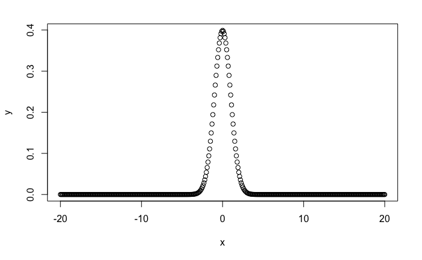

```r
x <- seq(-20,20,by=.1)
y <- dnorm(x)
plot(x,y)
```

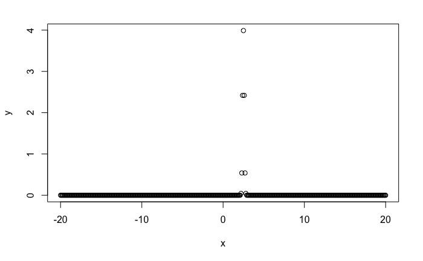

```r
y <- dnorm(x,mean=2.5,sd=0.1)
plot(x,y)
```

The second function we examine is pnorm. Given a number or a list it computes the probability that a normally distributed random number will be less than that number. This function also goes by the rather ominous title of the ???Cumulative Distribution Function.???

```r
pnorm(0)
```

```
[1] 0.5
```

```r
pnorm(1)
```

```
[1] 0.8413447
```

```r
pnorm(0,mean=2)
```

```
[1] 0.02275013
```

```r
pnorm(0,mean=2,sd=3)
```

```
[1] 0.2524925
```

```r
v <- c(0,1,2)
pnorm(v)
```

```
[1] 0.5000000 0.8413447 0.9772499
```

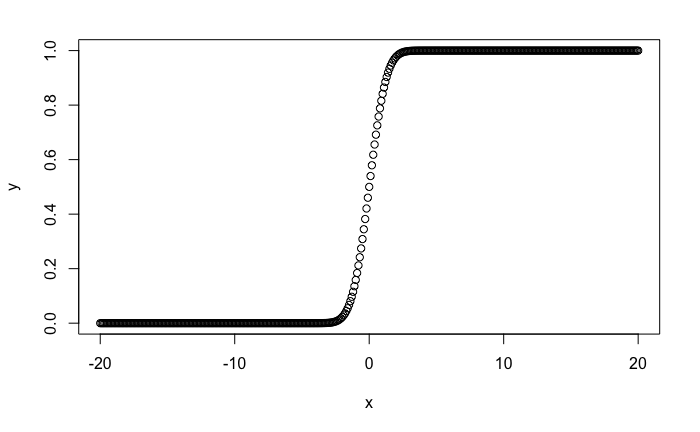

```r
x <- seq(-20,20,by=.1)
y <- pnorm(x)
plot(x,y)
```

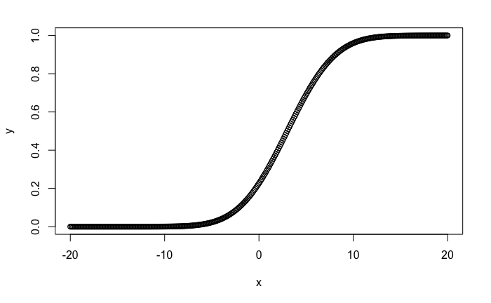

```r
y <- pnorm(x,mean=3,sd=4)
plot(x,y)
```

The next function we look at is qnorm which is the inverse of pnorm. The idea behind qnorm is that you give it a probability, and it returns the number whose cumulative distribution matches the probability

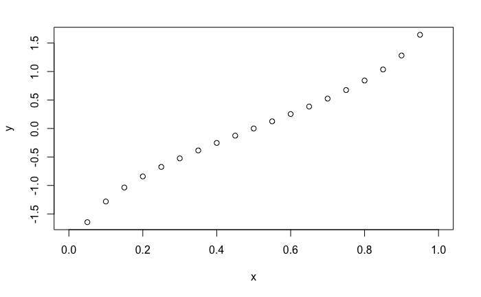

```r
x <- seq(0,1,by=.05)
y <- qnorm(x)
plot(x,y)
```

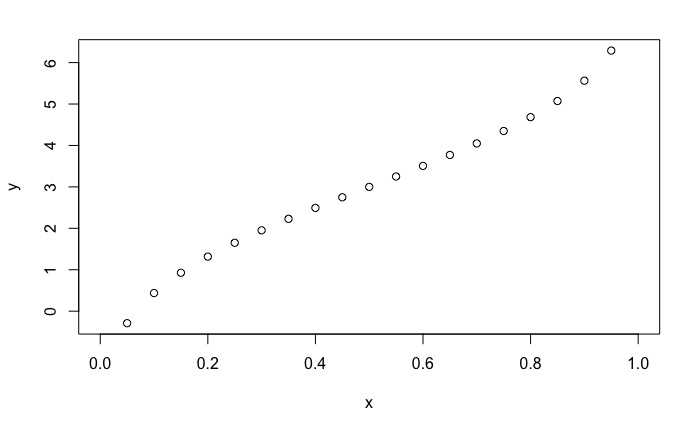

```r
y <- qnorm(x,mean=3,sd=2)
plot(x,y)
```

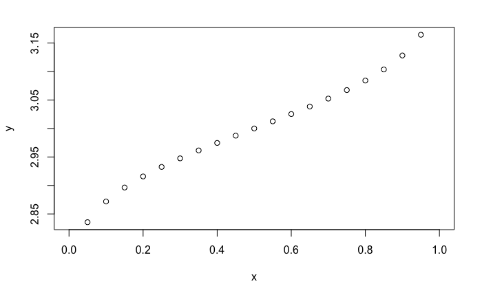

```r
y <- qnorm(x,mean=3,sd=0.1)
plot(x,y)
```

The last function we examine is the rnorm function which can generate random numbers whose distribution is normal.

```r
rnorm(4)
```

```
[1]  0.2645091 -1.0949282 -1.0465531 -0.3206520
```

```r
rnorm(4,mean=3)
```

```
[1] 1.690235 2.186922 2.651405 4.478016
```

```r
rnorm(4,mean=3,sd=3)
```

```
[1] 1.721511 5.212991 1.072576 2.867437
```

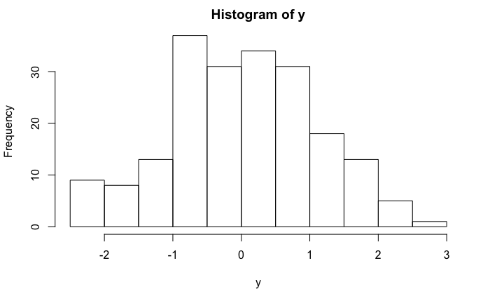

```r
y <- rnorm(200)
hist(y)
```

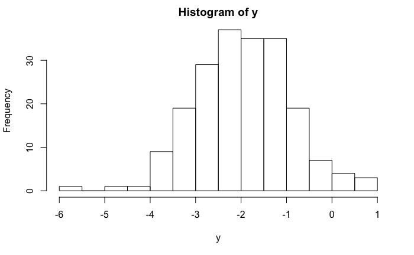

```r
y <- rnorm(200,mean=-2)
hist(y)
```

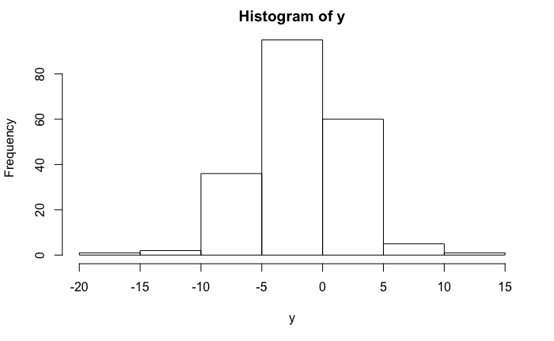

```r
y <- rnorm(200,mean=-2,sd=4)
hist(y)
```

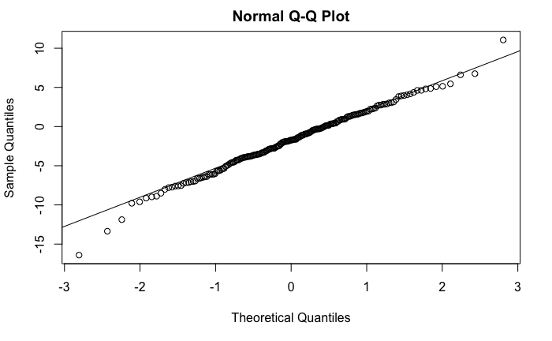

```r
qqnorm(y)
qqline(y)
```

## T Distribution

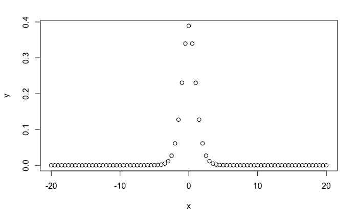

```r
x <- seq(-20,20,by=.5)
y <- dt(x,df=10)
plot(x,y)
```

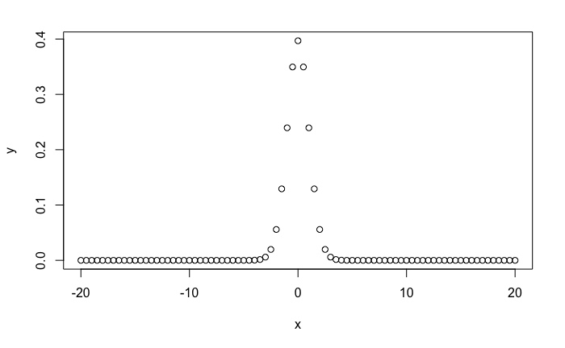

```r
y <- dt(x,df=50)
plot(x,y)
```

## Binomial Distribution

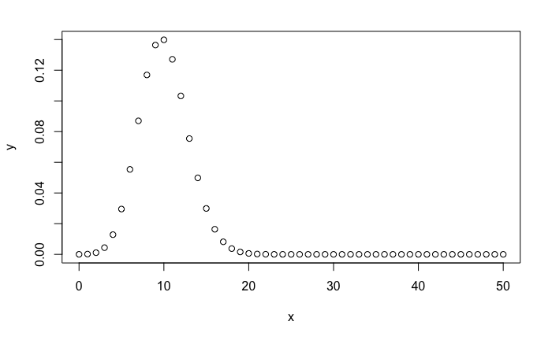

```r
x <- seq(0,50,by=1)
y <- dbinom(x,50,0.2)
plot(x,y)
```

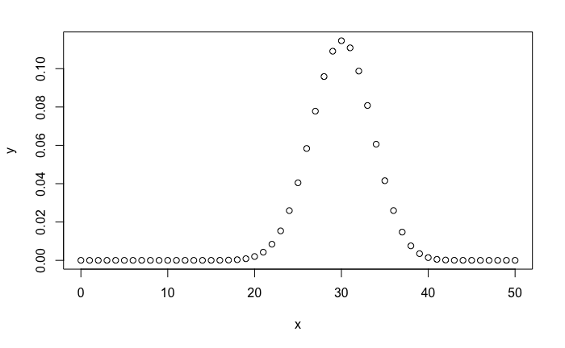

```r
y <- dbinom(x,50,0.6)
plot(x,y)
```

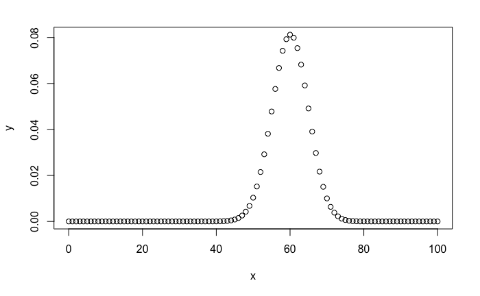

```r
x <- seq(0,100,by=1)
y <- dbinom(x,100,0.6)
plot(x,y)
```

## Chi-Squared Distriution

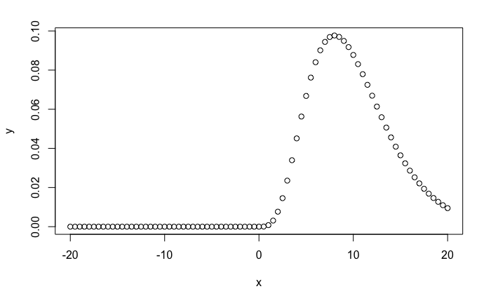

```r
x <- seq(-20,20,by=.5)
y <- dchisq(x,df=10)
plot(x,y)
```

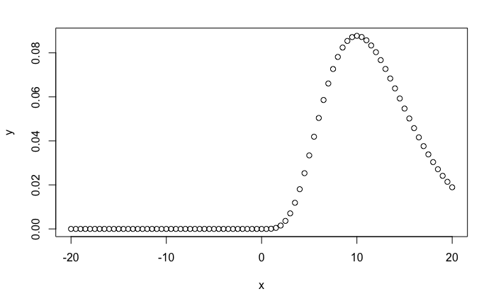

```r
y <- dchisq(x,df=12)
plot(x,y)
```

# Basic Plots

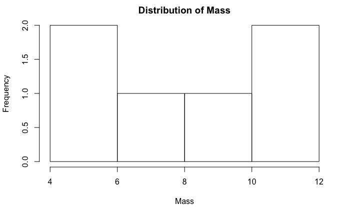

```r
hist(sample_data$mass,main="Distribution of Mass",xlab="Mass")
```

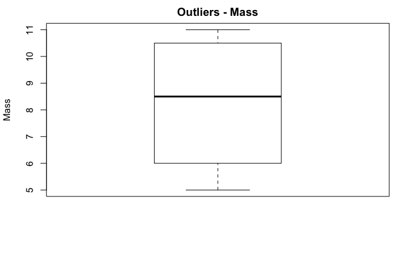

```r
boxplot(sample_data$mass, main="Outliers - Mass", ylab="Mass")
```

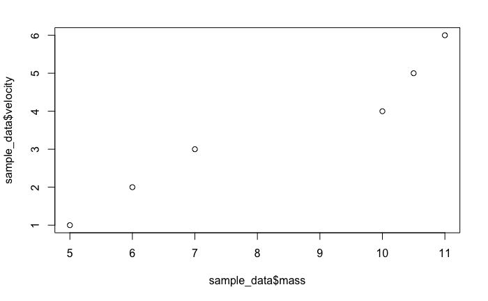

```r
plot(sample_data$mass,sample_data$velocity)
```

```r
x <- rnorm(10,sd=5,mean=20)
y <- 2.5*x - 1.0 + rnorm(10,sd=9,mean=0)
cor(x,y)
```

```
[1] 0.1991742
```

```r
x1 <- runif(8,15,25)
y1 <- 2.5*x1 - 1.0 + runif(8,-6,6)
x2 <- runif(8,15,25)
y2 <- 2.5*x2 - 1.0 + runif(8,-6,6)
plot(x,y,xlab="Independent",ylab="Dependent",main="Random Stuff")
points(x1,y1,col=2,pch=3)
```

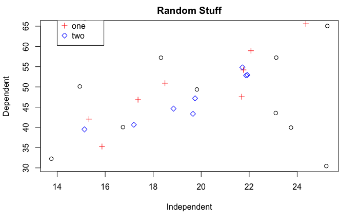

```r
points(x2,y2,col=4,pch=5)
legend(14,70,c("Original","one","two"),col=c(1,2,4),pch=c(1,3,5))
```